# W3cubDocs

/Qt

# QGradient Class

The QGradient class is used in combination with QBrush to specify gradient fills. More...

| Header: | #include <QGradient> |
| --- | --- |
| CMake: | find_package(Qt6 COMPONENTS Gui REQUIRED) target_link_libraries(mytarget PRIVATE Qt6::Gui) |
| qmake: | QT += gui |
| Inherited By: | QConicalGradient, QLinearGradient, and QRadialGradient |

- [List of all members, including inherited members](https://doc.qt.io/qt-6.2/qgradient-members.html)

## Public Types

| enum | **CoordinateMode** { LogicalMode, ObjectMode, StretchToDeviceMode, ObjectBoundingMode } |
| --- | --- |
| enum | **Preset** { WarmFlame, NightFade, SpringWarmth, JuicyPeach, YoungPassion, …, PerfectBlue } |
| enum | **Spread** { PadSpread, RepeatSpread, ReflectSpread } |
| enum | **Type** { LinearGradient, RadialGradient, ConicalGradient, NoGradient } |

## Public Functions

|  | **QGradient**(QGradient::Preset *preset*) |
| --- | --- |
| QGradient::CoordinateMode | **coordinateMode**() const |
| void | **setColorAt**(qreal *position*, const QColor &*color*) |
| void | **setCoordinateMode**(QGradient::CoordinateMode *mode*) |
| void | **setSpread**(QGradient::Spread *method*) |
| void | **setStops**(const QGradientStops &*stopPoints*) |
| QGradient::Spread | **spread**() const |
| QGradientStops | **stops**() const |
| QGradient::Type | **type**() const |
| bool | **operator!=**(const QGradient &*gradient*) const |
| bool | **operator==**(const QGradient &*gradient*) const |

## Related Non-Members

|  | **QGradientStop** |
| --- | --- |
|  | **QGradientStops** |

## Detailed Description

Qt currently supports three types of gradient fills:

- *Linear* gradients interpolate colors between start and end points.
- *Simple* radial gradients interpolate colors between a focal point and end points on a circle surrounding it.
- *Extended* radial gradients interpolate colors between a center and a focal circle.
- *Conical* gradients interpolate colors around a center point.

A gradient's type can be retrieved using the type() function. Each of the types is represented by a subclass of QGradient:

QLinearGradient

QRadialGradient

QConicalGradient

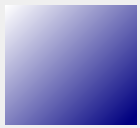

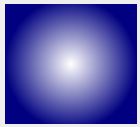

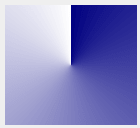

The colors in a gradient are defined using stop points of the QGradientStop type; i.e., a position and a color. Use the setColorAt() function to define a single stop point. Alternatively, use the setStops() function to define several stop points in one go. Note that the latter function *replaces* the current set of stop points.

It is the gradient's complete set of stop points (accessible through the stops() function) that describes how the gradient area should be filled. If no stop points have been specified, a gradient of black at 0 to white at 1 is used.

A diagonal linear gradient from black at (100, 100) to white at (200, 200) could be specified like this:

```
QLinearGradient linearGrad(QPointF(100, 100), QPointF(200, 200));
linearGrad.setColorAt(0, Qt::black);
linearGrad.setColorAt(1, Qt::white);
```

A gradient can have an arbitrary number of stop points. The following would create a radial gradient starting with red in the center, blue and then green on the edges:

```
QRadialGradient radialGrad(QPointF(100, 100), 100);
radialGrad.setColorAt(0, Qt::red);
radialGrad.setColorAt(0.5, Qt::blue);
radialGrad.setColorAt(1, Qt::green);
```

It is possible to repeat or reflect the gradient outside its area by specifying the spread method using the setSpread() function. The default is to pad the outside area with the color at the closest stop point. The currently set spread method can be retrieved using the spread() function. The QGradient::Spread enum defines three different methods:

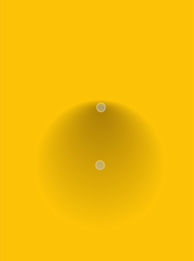

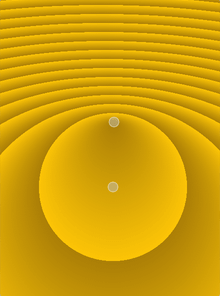

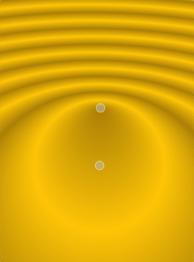

PadSpread

RepeatSpread

ReflectSpread

Note that the setSpread() function only has effect for linear and radial gradients. The reason is that the conical gradient is closed by definition, i.e. the *conical* gradient fills the entire circle from 0 - 360 degrees, while the boundary of a radial or a linear gradient can be specified through its radius or final stop points, respectively.

The gradient coordinates can be specified in logical coordinates, relative to device coordinates, or relative to object bounding box coordinates. The coordinate mode can be set using the setCoordinateMode() function. The default is LogicalMode, where the gradient coordinates are specified in the same way as the object coordinates. To retrieve the currently set coordinate mode use coordinateMode().

**See also** [The Gradients Example](https://doc.qt.io/qt-6.2/qtwidgets-painting-gradients-example.html) and QBrush.

## Member Type Documentation

### enum QGradient::CoordinateMode

This enum specifies how gradient coordinates map to the paint device on which the gradient is used.

[output not shown]

### `[since 5.12]`enum QGradient::Preset

This enum specifies a set of predefined presets for QGradient, based on the gradients from https://webgradients.com/.

| Constant | Value |
| --- | --- |
| `QGradient::WarmFlame` | `1` |
| `QGradient::NightFade` | `2` |
| `QGradient::SpringWarmth` | `3` |
| `QGradient::JuicyPeach` | `4` |
| `QGradient::YoungPassion` | `5` |
| `QGradient::LadyLips` | `6` |
| `QGradient::SunnyMorning` | `7` |
| `QGradient::RainyAshville` | `8` |
| `QGradient::FrozenDreams` | `9` |
| `QGradient::WinterNeva` | `10` |
| `QGradient::DustyGrass` | `11` |
| `QGradient::TemptingAzure` | `12` |
| `QGradient::HeavyRain` | `13` |
| `QGradient::AmyCrisp` | `14` |
| `QGradient::MeanFruit` | `15` |
| `QGradient::DeepBlue` | `16` |
| `QGradient::RipeMalinka` | `17` |
| `QGradient::CloudyKnoxville` | `18` |
| `QGradient::MalibuBeach` | `19` |
| `QGradient::NewLife` | `20` |
| `QGradient::TrueSunset` | `21` |
| `QGradient::MorpheusDen` | `22` |
| `QGradient::RareWind` | `23` |
| `QGradient::NearMoon` | `24` |
| `QGradient::WildApple` | `25` |
| `QGradient::SaintPetersburg` | `26` |
| `QGradient::PlumPlate` | `28` |
| `QGradient::EverlastingSky` | `29` |
| `QGradient::HappyFisher` | `30` |
| `QGradient::Blessing` | `31` |

[output cut: 138 more lines]

This enum was introduced or modified in Qt 5.12.

### enum QGradient::Spread

Specifies how the area outside the gradient area should be filled.

| Constant | Value | Description |
| --- | --- | --- |
| `QGradient::PadSpread` | `0` | The area is filled with the closest stop color. This is the default. |
| `QGradient::RepeatSpread` | `2` | The gradient is repeated outside the gradient area. |
| `QGradient::ReflectSpread` | `1` | The gradient is reflected outside the gradient area. |

**See also** spread() and setSpread().

### enum QGradient::Type

Specifies the type of gradient.

| Constant | Value | Description |
| --- | --- | --- |
| `QGradient::LinearGradient` | `0` | Interpolates colors between start and end points (QLinearGradient). |
| `QGradient::RadialGradient` | `1` | Interpolate colors between a focal point and end points on a circle surrounding it (QRadialGradient). |
| `QGradient::ConicalGradient` | `2` | Interpolate colors around a center point (QConicalGradient). |
| `QGradient::NoGradient` | `3` | No gradient is used. |

**See also** type().

## Member Function Documentation

### `[since 5.12]`QGradient::QGradient(QGradient::Preset *preset*)

Constructs a gradient based on a predefined *preset*.

The coordinate mode of the resulting gradient is QGradient::ObjectMode, allowing the preset to be applied to arbitrary object sizes.

This function was introduced in Qt 5.12.

### QGradient::CoordinateMode QGradient::coordinateMode() const

Returns the coordinate mode of this gradient. The default mode is LogicalMode.

**See also** setCoordinateMode().

### void QGradient::setColorAt(qreal *position*, const QColor &*color*)

Creates a stop point at the given *position* with the given *color*. The given *position* must be in the range 0 to 1.

**See also** setStops() and stops().

### void QGradient::setCoordinateMode(QGradient::CoordinateMode *mode*)

Sets the coordinate mode of this gradient to *mode*. The default mode is LogicalMode.

**See also** coordinateMode().

### void QGradient::setSpread(QGradient::Spread *method*)

Specifies the spread *method* that should be used for this gradient.

Note that this function only has effect for linear and radial gradients.

**See also** spread().

### void QGradient::setStops(const QGradientStops &*stopPoints*)

Replaces the current set of stop points with the given *stopPoints*. The positions of the points must be in the range 0 to 1, and must be sorted with the lowest point first.

**See also** setColorAt() and stops().

### QGradient::Spread QGradient::spread() const

Returns the spread method use by this gradient. The default is PadSpread.

**See also** setSpread().

### QGradientStops QGradient::stops() const

Returns the stop points for this gradient.

If no stop points have been specified, a gradient of black at 0 to white at 1 is used.

**See also** setStops() and setColorAt().

### QGradient::Type QGradient::type() const

Returns the type of gradient.

### bool QGradient::operator!=(const QGradient &*gradient*) const

**See also** operator==().

### bool QGradient::operator==(const QGradient &*gradient*) const

Returns `true` if the gradient is the same as the other *gradient* specified; otherwise returns `false`.

**See also** operator!=().

## Related Non-Members

### QGradientStop

Typedef for QPair<qreal, QColor>.

### QGradientStops

Typedef for QList<QGradientStop>.

© The Qt Company Ltd  
Licensed under the GNU Free Documentation License, Version 1.3.  
https://doc.qt.io/qt-6.2/qgradient.html